# ai-06-self_project

### Import libraries:

```python
import numpy as np
import pandas as pd
import matplotlib.pyplot as plt
from sklearn.cluster import KMeans
from scipy.cluster.hierarchy import linkage, dendrogram, fcluster
from mpl_toolkits.mplot3d import Axes3D
from sklearn.decomposition import PCA
from sklearn.preprocessing import StandardScaler
from mlxtend.frequent_patterns import apriori, association_rules
```

### Prepare data:

#### Load data:

```python
df = pd.read_csv("OnlineRetail.csv", skiprows=0, header=0)
display(df.head())
```

|  | InvoiceNo | StockCode | Description | Quantity | InvoiceDate | UnitPrice | CustomerID | Country |
| --- | --- | --- | --- | --- | --- | --- | --- | --- |
| 0 | 536365 | 85123A | WHITE HANGING HEART T-LIGHT HOLDER | 6 | 01-12-2010 08:26 | 2.55 | 17850.0 | United Kingdom |
| 1 | 536365 | 71053 | WHITE METAL LANTERN | 6 | 01-12-2010 08:26 | 3.39 | 17850.0 | United Kingdom |
| 2 | 536365 | 84406B | CREAM CUPID HEARTS COAT HANGER | 8 | 01-12-2010 08:26 | 2.75 | 17850.0 | United Kingdom |
| 3 | 536365 | 84029G | KNITTED UNION FLAG HOT WATER BOTTLE | 6 | 01-12-2010 08:26 | 3.39 | 17850.0 | United Kingdom |
| 4 | 536365 | 84029E | RED WOOLLY HOTTIE WHITE HEART. | 6 | 01-12-2010 08:26 | 3.39 | 17850.0 | United Kingdom |

#### Check data:

```python
df.isnull().any()
```

```
InvoiceNo      False
StockCode      False
Description     True
Quantity       False
InvoiceDate    False
UnitPrice      False
CustomerID      True
Country        False
dtype: bool
```

#### Delete null rows:

```python
df_na = df.dropna()
display(df_na.info())
```

```
<class 'pandas.core.frame.DataFrame'>
Int64Index: 406829 entries, 0 to 541908
Data columns (total 8 columns):
 #   Column       Non-Null Count   Dtype
---  ------       --------------   -----
 0   InvoiceNo    406829 non-null  object
 1   StockCode    406829 non-null  object
 2   Description  406829 non-null  object
 3   Quantity     406829 non-null  int64
 4   InvoiceDate  406829 non-null  object
 5   UnitPrice    406829 non-null  float64
 6   CustomerID   406829 non-null  float64
 7   Country      406829 non-null  object
dtypes: float64(2), int64(1), object(5)
memory usage: 27.9+ MB
```

```
None
```

```python
print(df_na.shape)
```

```
(406829, 8)
```

#### Change InvoiceDate to datetime data type:

```python
df_all = df_na.copy()
df_all["InvoiceDate"] = pd.to_datetime(df_all["InvoiceDate"])
df_all["InvoiceDate"] = df_all["InvoiceDate"].dt.date
display(df_all.head())
```

|  | InvoiceNo | StockCode | Description | Quantity | InvoiceDate | UnitPrice | CustomerID | Country |
| --- | --- | --- | --- | --- | --- | --- | --- | --- |
| 0 | 536365 | 85123A | WHITE HANGING HEART T-LIGHT HOLDER | 6 | 2010-01-12 | 2.55 | 17850.0 | United Kingdom |
| 1 | 536365 | 71053 | WHITE METAL LANTERN | 6 | 2010-01-12 | 3.39 | 17850.0 | United Kingdom |
| 2 | 536365 | 84406B | CREAM CUPID HEARTS COAT HANGER | 8 | 2010-01-12 | 2.75 | 17850.0 | United Kingdom |
| 3 | 536365 | 84029G | KNITTED UNION FLAG HOT WATER BOTTLE | 6 | 2010-01-12 | 3.39 | 17850.0 | United Kingdom |
| 4 | 536365 | 84029E | RED WOOLLY HOTTIE WHITE HEART. | 6 | 2010-01-12 | 3.39 | 17850.0 | United Kingdom |

#### Create 'Sale' column:

```python
df_all["Sale"] = df_all["Quantity"]*df_all["UnitPrice"]
display(df_all.head())
```

|  | InvoiceNo | StockCode | Description | Quantity | InvoiceDate | UnitPrice | CustomerID | Country | Sale |
| --- | --- | --- | --- | --- | --- | --- | --- | --- | --- |
| 0 | 536365 | 85123A | WHITE HANGING HEART T-LIGHT HOLDER | 6 | 2010-01-12 | 2.55 | 17850.0 | United Kingdom | 15.30 |
| 1 | 536365 | 71053 | WHITE METAL LANTERN | 6 | 2010-01-12 | 3.39 | 17850.0 | United Kingdom | 20.34 |
| 2 | 536365 | 84406B | CREAM CUPID HEARTS COAT HANGER | 8 | 2010-01-12 | 2.75 | 17850.0 | United Kingdom | 22.00 |
| 3 | 536365 | 84029G | KNITTED UNION FLAG HOT WATER BOTTLE | 6 | 2010-01-12 | 3.39 | 17850.0 | United Kingdom | 20.34 |
| 4 | 536365 | 84029E | RED WOOLLY HOTTIE WHITE HEART. | 6 | 2010-01-12 | 3.39 | 17850.0 | United Kingdom | 20.34 |

### RFM analysis:

We will conduct RFM analysis (based on recency, frequency, monetary value) to cluster customers into groups

#### Create RFM dataframe:

```python
rfm = pd.pivot_table(df_all, index="CustomerID", values="InvoiceNo", aggfunc=lambda x:x.nunique())
rfm.index = rfm.index.to_series().apply(lambda x: round(x))
display(rfm.head())
```

| CustomerID | InvoiceNo |
| --- | --- |
| 12346 | 2 |
| 12347 | 7 |
| 12348 | 4 |
| 12349 | 1 |
| 12350 | 1 |

#### R-value (recency):

```python
last_date = df_all["InvoiceDate"].max()
print(last_date)
```

```
2011-12-10
```

```python
df_pivot_r = pd.pivot_table(df_all, index="CustomerID", values="InvoiceDate", aggfunc="max")
rfm["R-value"] = last_date - df_pivot_r["InvoiceDate"]
```

```python
rfm["R-value"] = rfm["R-value"].dt.days
display(rfm.head())
```

| CustomerID | InvoiceNo | R-value |
| --- | --- | --- |
| 12346 | 2 | 326 |
| 12347 | 7 | 40 |
| 12348 | 4 | 76 |
| 12349 | 1 | 19 |
| 12350 | 1 | 311 |

#### F-value (frequency):

```python
# Number of invoice is already the number showing frequency of each customer
rfm.columns = ["F-value", "R-value"]
```

```python
display(rfm.head())
```

| CustomerID | F-value | R-value |
| --- | --- | --- |
| 12346 | 2 | 326 |
| 12347 | 7 | 40 |
| 12348 | 4 | 76 |
| 12349 | 1 | 19 |
| 12350 | 1 | 311 |

#### M-value (monetary):

```python
df_pivot_m = pd.pivot_table(df_all, index="CustomerID", values="Sale", aggfunc="sum")
rfm["M-value"] = df_pivot_m["Sale"]
display(rfm.head())
```

| CustomerID | F-value | R-value | M-value |
| --- | --- | --- | --- |
| 12346 | 2 | 326 | 0.00 |
| 12347 | 7 | 40 | 4310.00 |
| 12348 | 4 | 76 | 1797.24 |
| 12349 | 1 | 19 | 1757.55 |
| 12350 | 1 | 311 | 334.40 |

```python
rfm = rfm[["R-value", "F-value", "M-value"]]
display(rfm.head())
```

| CustomerID | R-value | F-value | M-value |
| --- | --- | --- | --- |
| 12346 | 326 | 2 | 0.00 |
| 12347 | 40 | 7 | 4310.00 |
| 12348 | 76 | 4 | 1797.24 |
| 12349 | 19 | 1 | 1757.55 |
| 12350 | 311 | 1 | 334.40 |

```python
last_date = df_all["InvoiceDate"].max()
rfm2 = df_all.groupby('CustomerID').agg({'InvoiceDate': lambda date: (last_date - date.max()).days,
                                        'InvoiceNo': lambda num: len(num),
                                        'Sale': lambda price: price.sum()})
rfm2.columns = ['R-value', 'F-value', 'M-value']
rfm2.index = rfm2.index.to_series().apply(lambda x: round(x))
display(rfm2.head())
```

| CustomerID | R-value | F-value | M-value |
| --- | --- | --- | --- |
| 12346 | 326 | 2 | 0.00 |
| 12347 | 40 | 182 | 4310.00 |
| 12348 | 76 | 31 | 1797.24 |
| 12349 | 19 | 73 | 1757.55 |
| 12350 | 311 | 17 | 334.40 |

#### Standardization:

```python
std_sc = StandardScaler()
std_sc.fit(rfm)
rfm_std = std_sc.transform(rfm)
display(rfm_std)
```

```
array([[ 1.97520461, -0.32936215, -0.23100099],
       [-0.53535955,  0.20610242,  0.29343167],
       [-0.21934448, -0.11517632, -0.01231622],
       ...,
       [-0.07011514, -0.22226923, -0.20951263],
       [-0.79870544,  1.16993863,  0.02390005],
       [-0.8864874 , -0.22226923, -0.00744423]])
```

### Conduct clustering:

#### Elbow method:

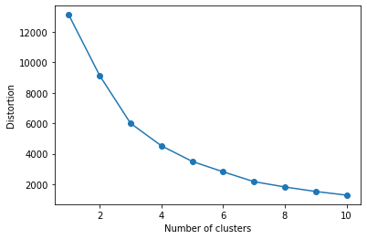

```python
distortions = []
for i in range(1, 11):
    km = KMeans(n_clusters=i)
    km.fit(rfm_std)
    distortions.append(km.inertia_)
plt.plot(range(1, 11), distortions, marker='o')
plt.xlabel('Number of clusters')
plt.ylabel('Distortion')
plt.show()
```

The optimum number is around 3~4.

#### **When n_cls=4:**

#### Execute clustering:

```python
n_cls = 4
km = KMeans(n_clusters=n_cls, random_state=29)
cls = km.fit_predict(rfm_std)
```

#### Results of clustering:

```python
rfm_cls0 = rfm[cls==0]
rfm_cls1 = rfm[cls==1]
rfm_cls2 = rfm[cls==2]
rfm_cls3 = rfm[cls==3]
```

```python
cls_list = [rfm_cls0, rfm_cls1, rfm_cls2, rfm_cls3]

for rfm_cls in cls_list:
    print(len(rfm_cls))
```

```
110
1078
6
3178
```

```python
rfm_diff = []
for rfm_cls in cls_list:
    rfm_diff.append(list(rfm_cls.describe().loc['mean', :]))
rfm_diff = pd.DataFrame(rfm_diff, index=["cls0", "cls1", "cls2", "cls3"], columns=rfm.columns)
display(rfm_diff)
```

|  | R-value | F-value | M-value |
| --- | --- | --- | --- |
| cls0 | 12.300000 | 40.672727 | 18441.961455 |
| cls1 | 265.236549 | 1.612245 | 427.471948 |
| cls2 | 7.000000 | 89.000000 | 182181.981667 |
| cls3 | 48.520138 | 4.859660 | 1484.437824 |

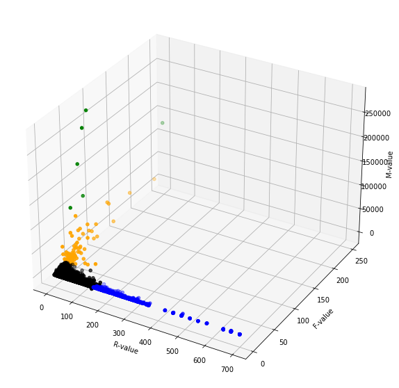

```python
fig = plt.figure(figsize=(10,10))
ax = fig.add_subplot(111, projection='3d')

colors = ["orange", "blue", "green", "black"]
for i in range(4):
    points = cls_list[i]
    ax.scatter(points["R-value"], points["F-value"], points["M-value"], color=colors[i], label="cls"+str(i))
ax.set_xlabel("R-value")
ax.set_ylabel("F-value")
ax.set_zlabel("M-value")
plt.show()
```

#### **When n_cls=3**

#### Execute clustering:

```python
n_cls = 3
km = KMeans(n_clusters=n_cls, random_state=29)
cls = km.fit_predict(rfm_std)
```

#### Results of clustering:

```python
rfm_cls0 = rfm[cls==0]
rfm_cls1 = rfm[cls==1]
rfm_cls2 = rfm[cls==2]
```

```python
print(len(rfm_cls0))
print(len(rfm_cls1))
print(len(rfm_cls2))
```

```
3225
1125
22
```

#### Check differences between clusters generated:

```python
rfm_diff = []
cls_list = [rfm_cls0, rfm_cls1, rfm_cls2]
for rfm_cls in cls_list:
    rfm_diff.append(list(rfm_cls.describe().loc['mean', :]))
rfm_diff = pd.DataFrame(rfm_diff, index=["cls0", "cls1", "cls2"], columns=rfm.columns)
display(rfm_diff)
```

|  | R-value | F-value | M-value |
| --- | --- | --- | --- |
| cls0 | 45.982326 | 5.721240 | 1842.668693 |
| cls1 | 260.455111 | 1.626667 | 432.146507 |
| cls2 | 9.636364 | 86.772727 | 85058.839091 |

#### Draw 3D plot based on clustering results:

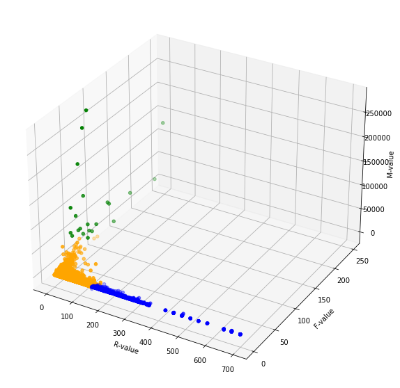

```python
fig = plt.figure(figsize=(10,10))
ax = fig.add_subplot(111, projection='3d')

colors = ["orange", "blue", "green"]
for i in range(3):
    points = cls_list[i]
    ax.scatter(points["R-value"], points["F-value"], points["M-value"], color=colors[i], label="cls"+str(i))
ax.set_xlabel("R-value")
ax.set_ylabel("F-value")
ax.set_zlabel("M-value")
plt.show()
```

#### Plot of results based on R-value and F-value:

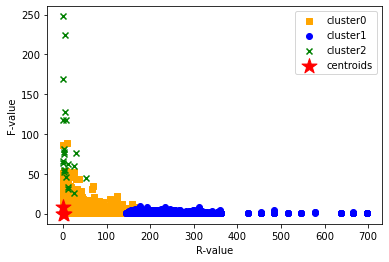

```python
colors = ['orange', 'blue', 'green']
markers = ['s', 'o', 'x']
for i in range(n_cls):
    df_cls = cls_list[i]
    plt.scatter(df_cls['R-value'], df_cls['F-value'],
                c=colors[i], marker=markers[i],
                label='cluster{}'.format(i))
plt.scatter(km.cluster_centers_[:, 0],
            km.cluster_centers_[:, 1],
            s=250, marker='*', c='red',
            label='centroids')
plt.xlabel('R-value')
plt.ylabel('F-value')
plt.legend()
plt.show()
```

### Conduct hierarchical clustering:

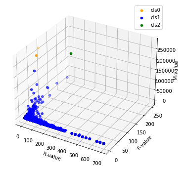

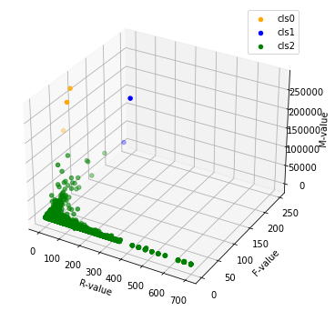

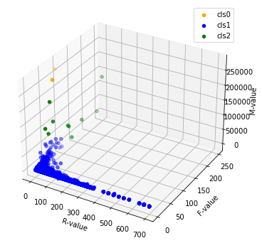

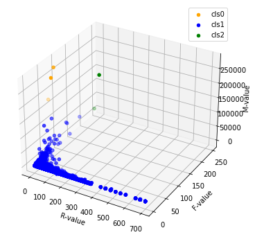

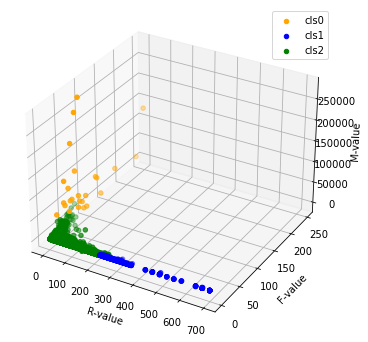

```python
n_clusters = 3

for lin in ['single', 'complete', 'centroid', 'average', 'ward']:
    Z = linkage(rfm_std, method=lin, metric='euclidean')
    cls = fcluster(Z, n_clusters, criterion='maxclust')

    fig = plt.figure(figsize=(6,6))
    ax = fig.add_subplot(111, projection='3d')

    colors = ["orange", "blue", "green"]
    for i in range(0, n_clusters):
        df_cls = rfm[ cls==i+1 ]
        ax.scatter(df_cls["R-value"], df_cls["F-value"], df_cls["M-value"], color=colors[i], label="cls"+str(i))
    ax.set_xlabel("R-value")
    ax.set_ylabel("F-value")
    ax.set_zlabel("M-value")
    plt.legend()
    plt.show()
```

**Comment:** Hierarchical clustering using Ward method and Euclidean distance results in quite the same cluster as k-means when n_cls=3.

#### Meaning of each cluster:

```python
display(rfm_diff)
```

|  | R-value | F-value | M-value |
| --- | --- | --- | --- |
| cls0 | 45.982326 | 5.721240 | 1842.668693 |
| cls1 | 260.455111 | 1.626667 | 432.146507 |
| cls2 | 9.636364 | 86.772727 | 85058.839091 |

> cls0: Customers who sometimes drop by the shop with moderate spendings and is likely to stop coming -> try to retain these customers

> cls1: Customers who just visited the shop 1 or 2 times and almost certainly would not come back -> little efforts should be invested

> cls2: Customers who drop by frequently with high spendings and is likely to visit the shop again -> special discounts should be given to these loyal customers.

#### List of customer IDs to retain:

```python
# cls0 (potential customers):
potential_ID = rfm_cls0.index
print(potential_ID)
```

```
Int64Index([12347, 12348, 12349, 12352, 12355, 12356, 12358, 12359, 12360,
            12362,
            ...
            18268, 18272, 18274, 18276, 18277, 18278, 18281, 18282, 18283,
            18287],
           dtype='int64', name='CustomerID', length=3225)
```

```python
# cls2 (loyal customers):
potential_ID = rfm_cls2.index
print(potential_ID)
```

```
Int64Index([12415, 12748, 13089, 13408, 13694, 13798, 14096, 14156, 14298,
            14606, 14646, 14911, 15061, 15311, 16029, 16422, 16684, 17450,
            17511, 17841, 17949, 18102],
           dtype='int64', name='CustomerID')
```

### Find out buying behaviors:

**Note:** We will find out groups of products that are often bought together using Apriori algorithm.

#### For simplicity, let's try using only data from Germany:

```python
df_ger = df_all[df_all["Country"]=="Germany"]
display(df_ger.head())
print(df_ger.shape)
```

|  | InvoiceNo | StockCode | Description | Quantity | InvoiceDate | UnitPrice | CustomerID | Country | Sale |
| --- | --- | --- | --- | --- | --- | --- | --- | --- | --- |
| 1109 | 536527 | 22809 | SET OF 6 T-LIGHTS SANTA | 6 | 2010-01-12 | 2.95 | 12662.0 | Germany | 17.7 |
| 1110 | 536527 | 84347 | ROTATING SILVER ANGELS T-LIGHT HLDR | 6 | 2010-01-12 | 2.55 | 12662.0 | Germany | 15.3 |
| 1111 | 536527 | 84945 | MULTI COLOUR SILVER T-LIGHT HOLDER | 12 | 2010-01-12 | 0.85 | 12662.0 | Germany | 10.2 |
| 1112 | 536527 | 22242 | 5 HOOK HANGER MAGIC TOADSTOOL | 12 | 2010-01-12 | 1.65 | 12662.0 | Germany | 19.8 |
| 1113 | 536527 | 22244 | 3 HOOK HANGER MAGIC GARDEN | 12 | 2010-01-12 | 1.95 | 12662.0 | Germany | 23.4 |

```
(9495, 9)
```

#### Create dataframe of buying behavior in Germany:

```python
basket_ger = (df_ger.groupby(['InvoiceNo', 'Description'])['Quantity']
          .sum().unstack().reset_index().fillna(0).set_index('InvoiceNo'))
display(basket_ger.head())
```

| Description InvoiceNo | 50'S CHRISTMAS GIFT BAG LARGE | DOLLY GIRL BEAKER | I LOVE LONDON MINI BACKPACK | RED SPOT GIFT BAG LARGE | SET 2 TEA TOWELS I LOVE LONDON | SPACEBOY BABY GIFT SET | 10 COLOUR SPACEBOY PEN | 12 COLOURED PARTY BALLOONS | 12 IVORY ROSE PEG PLACE SETTINGS | 12 MESSAGE CARDS WITH ENVELOPES | ... | YULETIDE IMAGES GIFT WRAP SET | ZINC HEART T-LIGHT HOLDER | ZINC STAR T-LIGHT HOLDER | ZINC BOX SIGN HOME | ZINC FOLKART SLEIGH BELLS | ZINC HEART LATTICE T-LIGHT HOLDER | ZINC METAL HEART DECORATION | ZINC T-LIGHT HOLDER STAR LARGE | ZINC T-LIGHT HOLDER STARS SMALL | ZINC WILLIE WINKIE CANDLE STICK |
| --- | --- | --- | --- | --- | --- | --- | --- | --- | --- | --- | --- | --- | --- | --- | --- | --- | --- | --- | --- | --- | --- |
| 536527 | 0.0 | 0.0 | 0.0 | 0.0 | 0.0 | 0.0 | 0.0 | 0.0 | 0.0 | 0.0 | ... | 0.0 | 0.0 | 0.0 | 0.0 | 0.0 | 0.0 | 0.0 | 0.0 | 0.0 | 0.0 |
| 536840 | 0.0 | 0.0 | 0.0 | 0.0 | 0.0 | 0.0 | 0.0 | 0.0 | 0.0 | 0.0 | ... | 0.0 | 0.0 | 0.0 | 0.0 | 0.0 | 0.0 | 0.0 | 0.0 | 0.0 | 0.0 |
| 536861 | 0.0 | 0.0 | 0.0 | 0.0 | 0.0 | 0.0 | 0.0 | 0.0 | 0.0 | 0.0 | ... | 0.0 | 0.0 | 0.0 | 0.0 | 0.0 | 0.0 | 0.0 | 0.0 | 0.0 | 0.0 |
| 536967 | 0.0 | 0.0 | 0.0 | 0.0 | 0.0 | 0.0 | 0.0 | 0.0 | 0.0 | 0.0 | ... | 0.0 | 0.0 | 0.0 | 0.0 | 0.0 | 0.0 | 0.0 | 0.0 | 0.0 | 0.0 |
| 536983 | 0.0 | 0.0 | 0.0 | 0.0 | 0.0 | 0.0 | 0.0 | 0.0 | 0.0 | 0.0 | ... | 0.0 | 0.0 | 0.0 | 0.0 | 0.0 | 0.0 | 0.0 | 0.0 | 0.0 | 0.0 |

5 rows × 1703 columns

#### Encode function:

```python
def encode_units(x):
    if x <= 0:
        return 0
    if x >= 1:
        return 1
```

#### Execute Apriori algorithm using mlxtend library:

```python
basket_ger = basket_ger.applymap(encode_units)
basket_ger.drop("POSTAGE", inplace=True, axis=1)
display(basket_ger.head())
```

| Description InvoiceNo | 50'S CHRISTMAS GIFT BAG LARGE | DOLLY GIRL BEAKER | I LOVE LONDON MINI BACKPACK | RED SPOT GIFT BAG LARGE | SET 2 TEA TOWELS I LOVE LONDON | SPACEBOY BABY GIFT SET | 10 COLOUR SPACEBOY PEN | 12 COLOURED PARTY BALLOONS | 12 IVORY ROSE PEG PLACE SETTINGS | 12 MESSAGE CARDS WITH ENVELOPES | ... | YULETIDE IMAGES GIFT WRAP SET | ZINC HEART T-LIGHT HOLDER | ZINC STAR T-LIGHT HOLDER | ZINC BOX SIGN HOME | ZINC FOLKART SLEIGH BELLS | ZINC HEART LATTICE T-LIGHT HOLDER | ZINC METAL HEART DECORATION | ZINC T-LIGHT HOLDER STAR LARGE | ZINC T-LIGHT HOLDER STARS SMALL | ZINC WILLIE WINKIE CANDLE STICK |
| --- | --- | --- | --- | --- | --- | --- | --- | --- | --- | --- | --- | --- | --- | --- | --- | --- | --- | --- | --- | --- | --- |
| 536527 | 0 | 0 | 0 | 0 | 0 | 0 | 0 | 0 | 0 | 0 | ... | 0 | 0 | 0 | 0 | 0 | 0 | 0 | 0 | 0 | 0 |
| 536840 | 0 | 0 | 0 | 0 | 0 | 0 | 0 | 0 | 0 | 0 | ... | 0 | 0 | 0 | 0 | 0 | 0 | 0 | 0 | 0 | 0 |
| 536861 | 0 | 0 | 0 | 0 | 0 | 0 | 0 | 0 | 0 | 0 | ... | 0 | 0 | 0 | 0 | 0 | 0 | 0 | 0 | 0 | 0 |
| 536967 | 0 | 0 | 0 | 0 | 0 | 0 | 0 | 0 | 0 | 0 | ... | 0 | 0 | 0 | 0 | 0 | 0 | 0 | 0 | 0 | 0 |
| 536983 | 0 | 0 | 0 | 0 | 0 | 0 | 0 | 0 | 0 | 0 | ... | 0 | 0 | 0 | 0 | 0 | 0 | 0 | 0 | 0 | 0 |

5 rows × 1702 columns

```python
frq_items_ger = apriori(basket_ger, min_support=0.01, use_colnames=True)
rules_ger = association_rules(frq_items_ger, metric ="lift", min_threshold = 1)
rules_ger = rules_ger.sort_values(['confidence', 'lift'], ascending =[False, False])
display(rules_ger.head())
```

|  | antecedents | consequents | antecedent support | consequent support | support | confidence | lift | leverage | conviction |
| --- | --- | --- | --- | --- | --- | --- | --- | --- | --- |
| 3229 | (BLUE VINTAGE SPOT BEAKER, GREEN VINTAGE SPOT ... | (RED VINTAGE SPOT BEAKER, PINK VINTAGE SPOT BE... | 0.011609 | 0.013267 | 0.011609 | 1.0 | 75.375 | 0.011455 | inf |
| 3316 | (ROUND SNACK BOXES SET OF 4 FRUITS , SCANDINAV... | (CHOCOLATE BOX RIBBONS , ROUND SNACK BOXES SET... | 0.011609 | 0.013267 | 0.011609 | 1.0 | 75.375 | 0.011455 | inf |
| 3317 | (ROUND SNACK BOXES SET OF4 WOODLAND , SCANDINA... | (CHOCOLATE BOX RIBBONS , ROUND SNACK BOXES SET... | 0.011609 | 0.013267 | 0.011609 | 1.0 | 75.375 | 0.011455 | inf |
| 484 | (STAR WREATH DECORATION WITH BELL) | (HEART WREATH DECORATION WITH BELL) | 0.011609 | 0.014925 | 0.011609 | 1.0 | 67.000 | 0.011435 | inf |
| 3188 | (WHITE SPOT BLUE CERAMIC DRAWER KNOB, RED SPOT... | (WHITE SPOT RED CERAMIC DRAWER KNOB, BLUE SPOT... | 0.013267 | 0.016584 | 0.013267 | 1.0 | 60.300 | 0.013047 | inf |

Comment: Based on this table, we may get the list of items that are bought together most oftenly in Germany's data.

#### Using all data:

```python
basket = (df_all.groupby(['InvoiceNo', 'Description'])['Quantity']
          .sum().unstack().reset_index().fillna(0).set_index('InvoiceNo'))
display(basket.head())
```

| Description InvoiceNo | 4 PURPLE FLOCK DINNER CANDLES | 50'S CHRISTMAS GIFT BAG LARGE | DOLLY GIRL BEAKER | I LOVE LONDON MINI BACKPACK | I LOVE LONDON MINI RUCKSACK | NINE DRAWER OFFICE TIDY | OVAL WALL MIRROR DIAMANTE | RED SPOT GIFT BAG LARGE | SET 2 TEA TOWELS I LOVE LONDON | SPACEBOY BABY GIFT SET | ... | ZINC STAR T-LIGHT HOLDER | ZINC SWEETHEART SOAP DISH | ZINC SWEETHEART WIRE LETTER RACK | ZINC T-LIGHT HOLDER STAR LARGE | ZINC T-LIGHT HOLDER STARS LARGE | ZINC T-LIGHT HOLDER STARS SMALL | ZINC TOP 2 DOOR WOODEN SHELF | ZINC WILLIE WINKIE CANDLE STICK | ZINC WIRE KITCHEN ORGANISER | ZINC WIRE SWEETHEART LETTER TRAY |
| --- | --- | --- | --- | --- | --- | --- | --- | --- | --- | --- | --- | --- | --- | --- | --- | --- | --- | --- | --- | --- | --- |
| 536365 | 0.0 | 0.0 | 0.0 | 0.0 | 0.0 | 0.0 | 0.0 | 0.0 | 0.0 | 0.0 | ... | 0.0 | 0.0 | 0.0 | 0.0 | 0.0 | 0.0 | 0.0 | 0.0 | 0.0 | 0.0 |
| 536366 | 0.0 | 0.0 | 0.0 | 0.0 | 0.0 | 0.0 | 0.0 | 0.0 | 0.0 | 0.0 | ... | 0.0 | 0.0 | 0.0 | 0.0 | 0.0 | 0.0 | 0.0 | 0.0 | 0.0 | 0.0 |
| 536367 | 0.0 | 0.0 | 0.0 | 0.0 | 0.0 | 0.0 | 0.0 | 0.0 | 0.0 | 0.0 | ... | 0.0 | 0.0 | 0.0 | 0.0 | 0.0 | 0.0 | 0.0 | 0.0 | 0.0 | 0.0 |
| 536368 | 0.0 | 0.0 | 0.0 | 0.0 | 0.0 | 0.0 | 0.0 | 0.0 | 0.0 | 0.0 | ... | 0.0 | 0.0 | 0.0 | 0.0 | 0.0 | 0.0 | 0.0 | 0.0 | 0.0 | 0.0 |
| 536369 | 0.0 | 0.0 | 0.0 | 0.0 | 0.0 | 0.0 | 0.0 | 0.0 | 0.0 | 0.0 | ... | 0.0 | 0.0 | 0.0 | 0.0 | 0.0 | 0.0 | 0.0 | 0.0 | 0.0 | 0.0 |

5 rows × 3896 columns

```python
basket = basket.applymap(encode_units)
basket.drop("POSTAGE", inplace=True, axis=1)
display(basket.head())
```

| Description InvoiceNo | 4 PURPLE FLOCK DINNER CANDLES | 50'S CHRISTMAS GIFT BAG LARGE | DOLLY GIRL BEAKER | I LOVE LONDON MINI BACKPACK | I LOVE LONDON MINI RUCKSACK | NINE DRAWER OFFICE TIDY | OVAL WALL MIRROR DIAMANTE | RED SPOT GIFT BAG LARGE | SET 2 TEA TOWELS I LOVE LONDON | SPACEBOY BABY GIFT SET | ... | ZINC STAR T-LIGHT HOLDER | ZINC SWEETHEART SOAP DISH | ZINC SWEETHEART WIRE LETTER RACK | ZINC T-LIGHT HOLDER STAR LARGE | ZINC T-LIGHT HOLDER STARS LARGE | ZINC T-LIGHT HOLDER STARS SMALL | ZINC TOP 2 DOOR WOODEN SHELF | ZINC WILLIE WINKIE CANDLE STICK | ZINC WIRE KITCHEN ORGANISER | ZINC WIRE SWEETHEART LETTER TRAY |
| --- | --- | --- | --- | --- | --- | --- | --- | --- | --- | --- | --- | --- | --- | --- | --- | --- | --- | --- | --- | --- | --- |
| 536365 | 0 | 0 | 0 | 0 | 0 | 0 | 0 | 0 | 0 | 0 | ... | 0 | 0 | 0 | 0 | 0 | 0 | 0 | 0 | 0 | 0 |
| 536366 | 0 | 0 | 0 | 0 | 0 | 0 | 0 | 0 | 0 | 0 | ... | 0 | 0 | 0 | 0 | 0 | 0 | 0 | 0 | 0 | 0 |
| 536367 | 0 | 0 | 0 | 0 | 0 | 0 | 0 | 0 | 0 | 0 | ... | 0 | 0 | 0 | 0 | 0 | 0 | 0 | 0 | 0 | 0 |
| 536368 | 0 | 0 | 0 | 0 | 0 | 0 | 0 | 0 | 0 | 0 | ... | 0 | 0 | 0 | 0 | 0 | 0 | 0 | 0 | 0 | 0 |
| 536369 | 0 | 0 | 0 | 0 | 0 | 0 | 0 | 0 | 0 | 0 | ... | 0 | 0 | 0 | 0 | 0 | 0 | 0 | 0 | 0 | 0 |

5 rows × 3895 columns

```python
frq_items = apriori(basket, min_support=0.02, use_colnames=True)
rules = association_rules(frq_items, metric ="lift", min_threshold = 0)
rules = rules.sort_values(['confidence', 'lift'], ascending =[False, False])
display(rules.head())
```

|  | antecedents | consequents | antecedent support | consequent support | support | confidence | lift | leverage | conviction |
| --- | --- | --- | --- | --- | --- | --- | --- | --- | --- |
| 5 | (PINK REGENCY TEACUP AND SAUCER) | (GREEN REGENCY TEACUP AND SAUCER) | 0.025056 | 0.031140 | 0.020730 | 0.827338 | 26.568210 | 0.019950 | 5.611313 |
| 6 | (GREEN REGENCY TEACUP AND SAUCER) | (ROSES REGENCY TEACUP AND SAUCER ) | 0.031140 | 0.035286 | 0.024380 | 0.782923 | 22.187826 | 0.023282 | 4.444115 |
| 3 | (GARDENERS KNEELING PAD CUP OF TEA ) | (GARDENERS KNEELING PAD KEEP CALM ) | 0.028616 | 0.034069 | 0.020865 | 0.729134 | 21.401429 | 0.019890 | 3.566081 |
| 7 | (ROSES REGENCY TEACUP AND SAUCER ) | (GREEN REGENCY TEACUP AND SAUCER) | 0.035286 | 0.031140 | 0.024380 | 0.690932 | 22.187826 | 0.023282 | 3.134782 |
| 1 | (ALARM CLOCK BAKELIKE GREEN) | (ALARM CLOCK BAKELIKE RED ) | 0.035557 | 0.039522 | 0.023885 | 0.671736 | 16.996386 | 0.022479 | 2.925934 |

**Comment:** Since most data is for customers in the UK, it seems that UK customers (who are tea lovers) often buy teacup and saucer of different colors together.